# Customizing `superb` plots

Creating a plot involves reading raw data and compiling these into summary statistics. This step is handled by `superb` transparently. The second, more involving step, however is to customize the plots so that it looks appealing to the readers.

In this vignette, we go rapidly over `superb` functionalities. Instead, we provide worked-out examples producing fully customized plots. We proceed with examples taken from scientific articles. The first example produces a rain-drop plot, the second a bar plot whose origin is not zero.

In the following, we need the following libraries:

```r
## Load relevant packages
library(superb)             # for superbPlot
library(ggplot2)            # for all the graphic directives
library(gridExtra)          # for grid.arrange
```

If they are not present on your computer, first upload them to your computer with `install.packages("name of the package")`.

# Figure 2 of Hofer, Langmann, Burkart and Neubauer, 2022.

In their study, Hofer, Langmann, Burkart, & Neubauer (2022) examined who is the best judges of one’s abilities. Examining self-ratings vs. other-ratings in six domain, they found out that we are not always the best judges. They present in their Figure 2 a rain-cloud plot (Allen, Poggiali, Whitaker, Marshall, & Kievit (2019)) illustrating the ratings.

In what follow, we discuss how this plot could be customized after its initial creation with `superb`.

As the six domains are within-subject ratings, the data must be composed of 6 columns (at least, there can be additional columns; they won’t be illustrated herein). In case you do not have such data, the following subsection generates mock data.

## Generating mock data

We generate two sets of mock data from six sets of means and standard deviations:

```r
Astats <- data.frame(
    MNs = c(6.75, 6.00, 5.50, 6.50, 8.00, 8.75),
    SDs = c(2.00, 3.00, 3.50, 3.50, 1.25, 1.25)
)
dtaA <- apply(Astats, 1,
    function(stat) {rnorm(100, mean=stat[1], sd=stat[2])}
)
dtaA <- data.frame(dtaA)
colnames(dtaA) <- c("Verbal", "Numerical", "Spatial", "Creativity", "Intrapersonal", "Interpersonal")

Bstats <- data.frame(
    MNs = c(3.33, 3.00, 2.50, 3.00, 2.75, 3.50),
    SDs = c(0.25, 0.50, 0.66, 0.50, 0.25, 0.25)
)
dtaB <- apply(Bstats, 1,
    function(stat) {rnorm(100, mean=stat[1], sd=stat[2])}
)
dtaB <- data.frame(dtaB)
colnames(dtaB) <- c("Verbal", "Numerical", "Spatial", "Creativity", "Intrapersonal", "Interpersonal")
```

The datasets are `data.frame`s called `dtaA` and `dtaB`. Their columns names are the dependent variables, e.g., “Verbal”, “Numerical”, “Spatial”, “Creativity”, “Intrapersonal”, “Interpersonal”.

## Making the top-row plot

For convenience, we make lists of the desired colors and labels we want to appear on the x-axis:

```r
mycolors <- c("seagreen","chocolate2","mediumpurple3","deeppink","chartreuse4", "darkgoldenrod1")
mylabels <- c("Verbal", "Numerical", "Spatial", "Creativity", "Intrapersonal", "Interpersonal")
```

We are ready to make the plot with the desired adjustments:

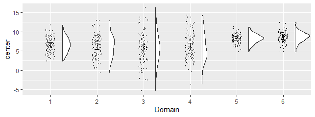

Figure 2, preliminary version

```r
pltA <- superb(
    crange(Verbal, Interpersonal) ~ ., # no between-subject factors
    dtaA,                       # plot for the first data set...
    WSFactors   = "Domain(6)",  # ...a within-subject design with 6 levels
    adjustments = list(
        purpose = "difference", # we want to compare means
        decorrelation = "CM"    # and error bars are correlated-adjusted
    ),
    plotStyle="raincloud",

    # the following (optional) arguments are adjusting some of the visuals
    pointParams    = list(size = 0.75),
    jitterParams   = list(width =0.1, shape=21,size=0.05,alpha=1), # less dispersed jitter dots,
    violinParams   = list(trim=TRUE, alpha=1),                     # not transparent,
    errorbarParams = list(width = 0.1, linewidth=0.5)              # wider bars, thicker lines.
)
pltA
```

As seen, this plot is a standard, colorless, plot. It contains all that is needed; it is just plain drab and the labels are generic ones (on the vertical axis and on the horizontal axis).

## Adding a color layer to the plot

Using `superb`, if there is only one factor, superb will consider that it is the one on the x-axis and there is therefore no other layers in the plot. This is why the current plot is colorless.

It is possible, post-hoc, to indicate that we wish additional layers in the plot.

In the present, we want to add the `fill` and the `color` of dots layers. These layers are to be “connected” to the sole factor in the present example (that is, `Domain`). Consequently, the x-axis labels, the fill color and the dot color are all redondant information identifying the condition.

To do this, simply add an aesthetic graphic directive to `pltA` with:

```r
pltA + aes(fill = factor(Domain), colour = factor(Domain))
```

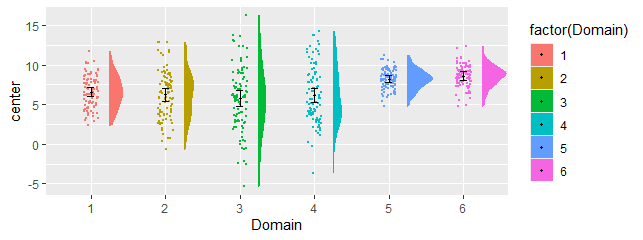

Figure 2, version with colors

## Adding graphic directives for fine-tuning the plot

We can customize any `superb` plot by adding graphic directives one-by-one using the operator `+`, or we can collect all the directives in a list, and add this list once. As we have two plots with mostly the same directives, we use this second approach.

These changes are all collected within the list `commonstyle` below:

```r
commonstyle <- list(
    theme_classic(),                             # It has no background, no bounding box.

    # We customize this theme further:
    theme(axis.line=element_line(linewidth=0.50), # We make the axes thicker...
        axis.text = element_text(size = 10),      # their text bigger...
        axis.title = element_text(size = 12),     # their labels bigger...
        plot.title = element_text(size = 10),     # and the title bigger as well.
        panel.grid = element_blank(),             # We remove the grid lines
        legend.position = "none"                  # ... and we hide the side legend.
    ),

    # Finally, we place tick marks on the units
    scale_y_continuous( breaks=1:10 ),

    # set the labels to be displayed
    scale_x_discrete(name="Domain", labels = mylabels),

    # and set colours to both colour and fill layers
    scale_discrete_manual(aesthetic =c("fill","colour"), values = mycolors)
)
```

We also changed the vertical scale (tick marks at designated positions) and the horizontal scale with names on the tick marks (sadly, `superb` replaces them with consecutive numbers…) and colors to fill the clouds (`fill`) and their borders (`colour`) as well as the rain drop colors.

Examining this plot with the `commonstyle` added, we get

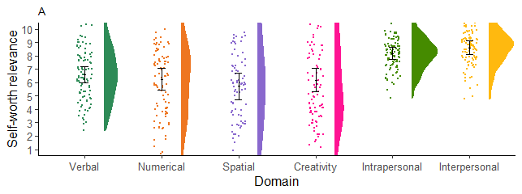

Figure 2, final version

```r
finalpltA <- pltA + aes(fill = factor(Domain), colour = factor(Domain)) +
    commonstyle +                           # all the above directive are added;
    coord_cartesian( ylim = c(1,10) ) +     # the y-axis bounds are given ;
    labs(title="A") +                       # the plot is labeled "A"...
    ylab("Self-worth relevance")            # and the y-axis label given.
finalpltA
```

## Making the second row of the figure

We do exactly the same for the second plot. We just change the data set to `dtaB` and in the last graphic directives, using options tailored specifically to this second data set (smaller y-axis range, different label, etc.):

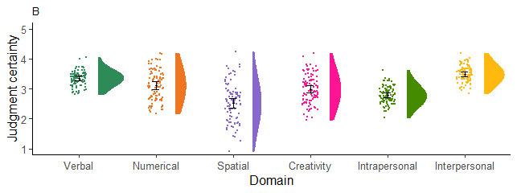

Figure 2, bottom row

```r
pltB <- superb(
    crange(Verbal, Interpersonal) ~ ., # no between-subject factors
    dtaB,                       # the second data set...
    WSFactors = "Domain(6)",    # ...a within-subject design with 6 levels
    adjustments = list(
        purpose = "difference", # we want to compare means
        decorrelation = "CM"    # and error bars are correlated-adjusted
    ),
    plotStyle="raincloud",
    # the following (optional) arguments are adjusting some of the visuals
    pointParams    = list(size = 0.75),
    jitterParams = list(width =0.1, shape=21,size=0.05,alpha=1), # less dispersed jitter dots,
    violinParams = list(trim=TRUE, alpha=1,adjust=3),            # not semi-transparent, smoother
    errorbarParams = list(width = 0.1, linewidth=0.5)                 # wider bars, thicker lines.
)
finalpltB <- pltB + aes(fill = factor(Domain), colour = factor(Domain)) +
    commonstyle +                           # the following three lines are the differences:
    coord_cartesian( ylim = c(1,5) ) +      # the limits, 1 to 5, are different
    labs(title="B") +                       # the plot is differently-labeled
    ylab("Judgment certainty")              # and the y-axis label differns.
finalpltB
```

## Combining and saving both plots

Finally, we assemble the two plots together

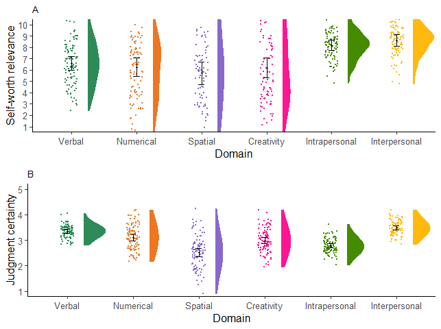

Figure 2, final version

```r
finalplt <- grid.arrange(finalpltA, finalpltB, ncol=1)
```

It can be saved with high-resolution if desired with

```r
ggsave( "Figure2.png",
    plot=finalplt,
    device = "png",
    dpi = 320,          # pixels per inche
    units = "cm",       # or "in" for dimensions in inches
    width = 17,         # as found in the article
    height = 13
)
```

That’s it!